# 作业2

## 1. 题目

### 20742: 泰波拿契數

http://cs101.openjudge.cn/practice/20742/

思路： 采用斐波那契数相同的做法，其实也可以使用列表进行记录，但那样不如这种方法快。

代码：

```
n=int(input())
a=0
b=1
c=1
if n==1 or n==2:
    print(1)
else:
    for i in range(2,n):
        a,b,c=b,c,a+b+c
    print(c)
```

代码运行截图 （至少包含有"Accepted"）

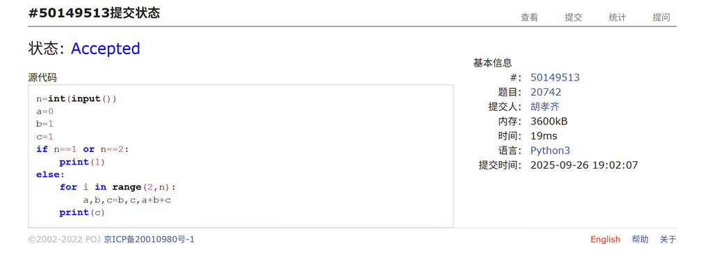

### 58A. Chat room

greedy/strings, 1000, http://codeforces.com/problemset/problem/58/A

思路： 本题简单，直接遍历字符串，逐个匹配字母，最终验证是否完成匹配即可，复杂度N

代码：

```
s=input()
n=0
a=["h","e","l","l","o"]
for i in range(len(s)):
    if s[i]==a[n]:
        n+=1
        if n==5:
            break
if n==5:
    print("YES")
else:
    print("NO")
```

代码运行截图 （至少包含有"Accepted"）

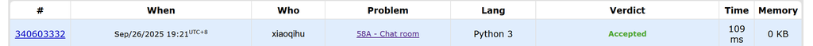

### 118A. String Task

implementation/strings, 1000, http://codeforces.com/problemset/problem/118/A

思路： 简单题，只需要遍历字符串，取出非元音字母并将其转为小写，以要求格式输出即可

代码：

```
s=input()
l=[]
a=["A","E","I","O","U",'Y','a','e','i','o','u','y']
for i in range(len(s)):
    if s[i] not in a:
        b=s[i]
        if ord("A")<=ord(s[i])<=ord('Z'):
            b=chr(ord(s[i])-ord("A")+ord('a'))
        l.append(b)
for i in range(len(l)):
    print("."+l[i],end="")
```

代码运行截图 （至少包含有"Accepted"）

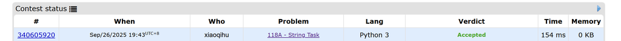

### 22359: Goldbach Conjecture

http://cs101.openjudge.cn/practice/22359/

代码：

```
n=int(input())
prime=[1]*(n+1)
prime[0]=prime[1]=0
for i in range(2,int(n**0.5)+1):
    if prime[i]:
        for j in range(i**2,n+1,i):
            prime[j]=0
for i in range(n+1):
    if prime[i] and prime[n-i]:
        print(i,end=' ')
        print(n-i)
        break
```

代码运行截图 （至少包含有"Accepted"）

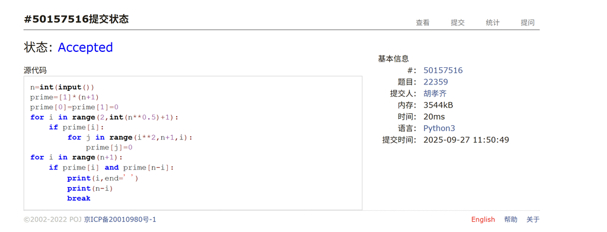

### E23563: 多项式时间复杂度

http://cs101.openjudge.cn/pctbook/E23563/

思路： 先将多项式各项分开，然后以n为界找出系数和指数部分，记录系数不为0的最大指数。

代码

```
l=input().split('+')
m=0
for i in range(len(l)):
    li=len(l[i])
    for j in range(li):
        if l[i][j]=='n':
            if j==0:
                a=1
            else:
                a=int(l[i][:j])
            b=int(l[i][j+2:])
    if a!=0 and b>m:
        m=b
print('n^'+str(m))
```

（至少包含有"Accepted"）

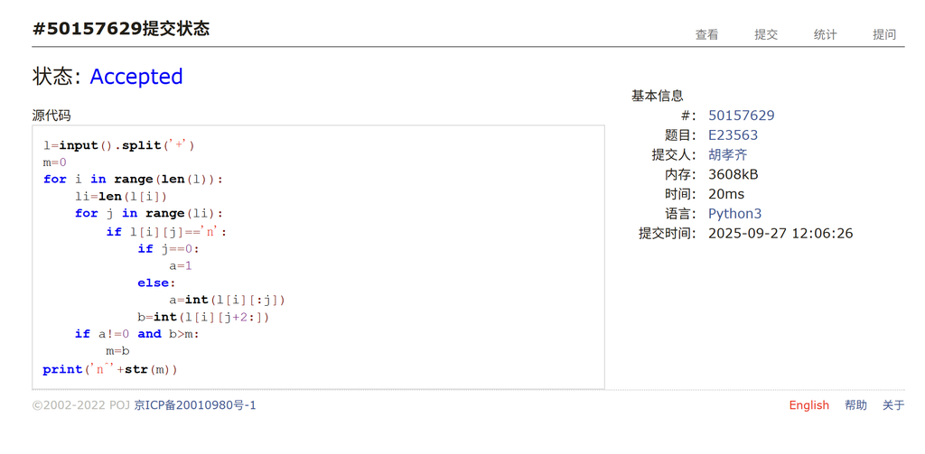

### 24684: 直播计票

http://cs101.openjudge.cn/practice/24684/

思路： 使用字典进行计数，然后放入列表中进行排序，输出票数最多的结果

代码

```
from collections import defaultdict
l=list(map(int,input().split()))
dic=defaultdict(int)
for i in range(len(l)):
    dic[l[i]]+=1
l1=[]
for key in dic:
    l1.append([dic[key],key])
l1.sort(key=lambda x:(-x[0],x[1]))
i=0
ans=[]
while i<len(l1) and l1[i][0]==l1[0][0]:
    ans.append(l1[i][1])
    i+=1
print(*ans)
```

（至少包含有"Accepted"）

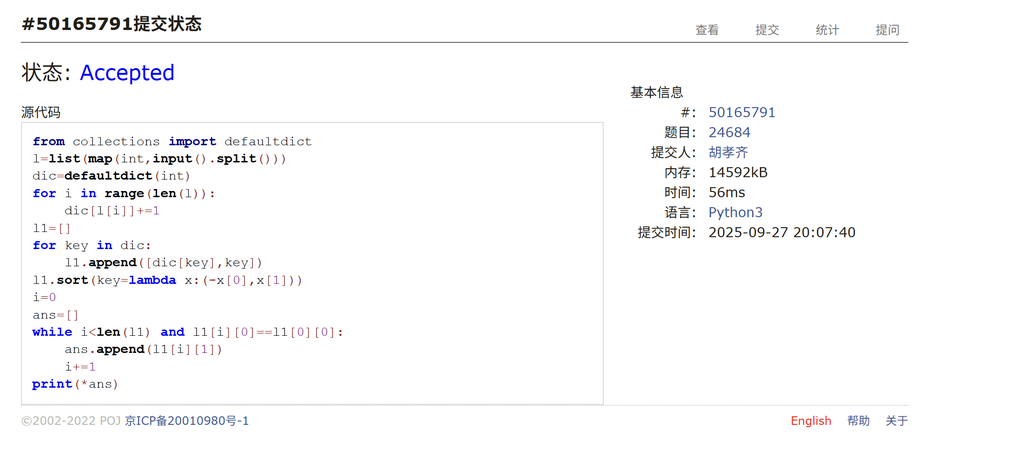

## 2. 学习总结和个人收获

如果发现作业题目相对简单，有否寻找额外的练习题目，如“数算2025fall每日选做”、LeetCode、Codeforces、洛谷等网站上的题目。 做了每日选做和部分力扣100热题。本次作业中，学习了埃氏素数筛的写法，温习了关于输入和输出方法的语法。